# Final project

Xinyun (Stacy) Li, Qiuyue Kong, Wenxu Liu, Siwei Stella Zhu

12/1/2021

```r
library(tidyverse)
library(dplyr)
library(lubridate)
library(caret)
library(MASS)
library(rpart)
library(randomForest)
library(zoo)
```

```r
library(maps)
library(gridExtra)
vaccine<-read.csv("COVID-19_Vaccinations_in_the_United_States_Jurisdiction.csv")
case_death<-read.csv("United_States_COVID-19_Cases_and_Deaths_by_State_over_Time.csv")
```

```r
USstate=c("AL","AK","AZ","AR","CA","CO","CT","DE","FL","GA","HI","ID","IL","IN","IA","KS",
          "KY","LA","ME","MD","MA","MI","MN","MS","MO","MT","NE","NV","NH","NJ","NM","NY",
          "NC","ND","OH","OK","OR","PA","RI","SC","SD","TN","TX","UT","VT","VA","WA","WV",
          "WI","WY")
case_death<-case_death %>%
  transmute(date=mdy(submission_date),
            state=state,
            tot_case=tot_cases,
            tot_death=tot_death,
            new_case=new_case,
            new_death=new_death
            ) %>%
  filter(state %in% USstate) %>%
  filter(date >= as.Date("2021-01-01") & date<=as.Date("2021-11-30"))
```

```r
vaccine<-vaccine %>%
  dplyr::select(c(1,3,13,14,15,16,17,18,19,26,28,30,32,34,36,38,40,42,43,44,46,47,48,50,51,52,54,55,56,58,60,62,64,66,67,68)) %>%
  rename(state=Location) %>%
  mutate(date=mdy(Date)) %>%
  dplyr::select(-Date)
```

Combine two tables into #comb# #new_comb_ma# contains only data in MA

```r
comb<-right_join(vaccine,case_death,by=c("date","state"))
#write.csv(comb,"bigtable.csv",row.names = FALSE)
new_comb_ma<-comb%>%
  filter(state=="MA")%>%
  arrange(date)
  #mutate(new_case=tot_case-lag(tot_case)) %>%
  #mutate(new_death=tot_death-lag(tot_death))%>%
  #mutate(new_adm=Administered-lag(Administered)) %>%
  #mutate(new_jj=Administered_Janssen-lag(Administered_Janssen)) %>%
  #mutate(new_moderna=Administered_Moderna-lag(Administered_Moderna))%>%
  #mutate(new_pfizer=Administered_Pfizer-lag(Administered_Pfizer))
```

The number of new cases against date in MA

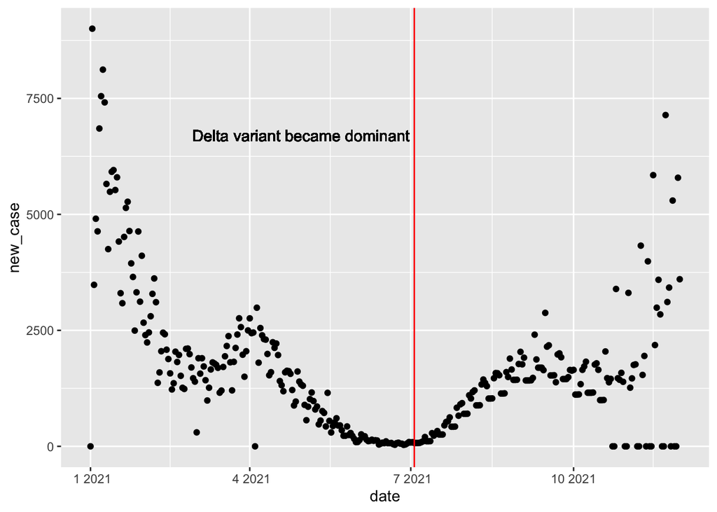

```r
new_comb_ma%>%ggplot(aes(x=date))+
  geom_point(aes(y=new_case))+
  geom_vline(xintercept=as.Date("2021-07-03"),color="red")+
  geom_text(aes(x=as.Date("2021-04-30"),y=6700,label="Delta variant became dominant"))
```

The number of new death against date in MA

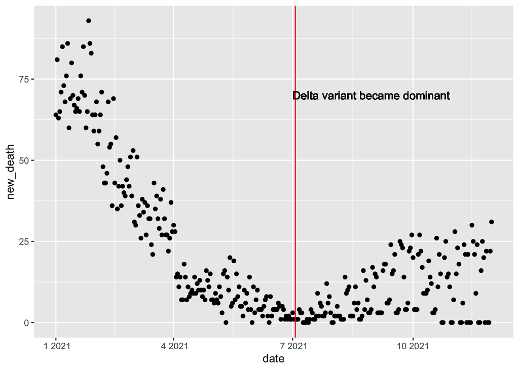

```r
new_comb_ma%>%ggplot(aes(date,new_death))+
  geom_point()+
  geom_vline(xintercept=as.Date("2021-07-03"),color="red")+
  geom_text(aes(x=as.Date("2021-08-30"),y=70,label="Delta variant became dominant"))
```

The change of new cases across all states

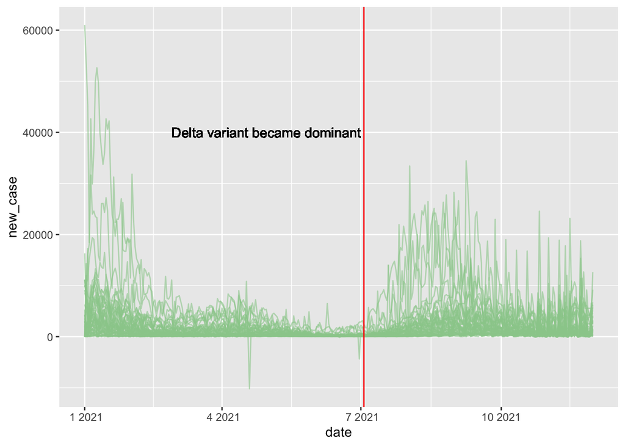

```r
comb%>%
  ggplot(aes(date,new_case,group=state))+
  geom_line(color='darkseagreen3',alpha=0.6)+
  geom_vline(xintercept=as.Date("2021-07-03"),color="red")+
  geom_text(aes(x=as.Date("2021-04-30"),y=40000,label="Delta variant became dominant"))
```

The change of new deaths across all states

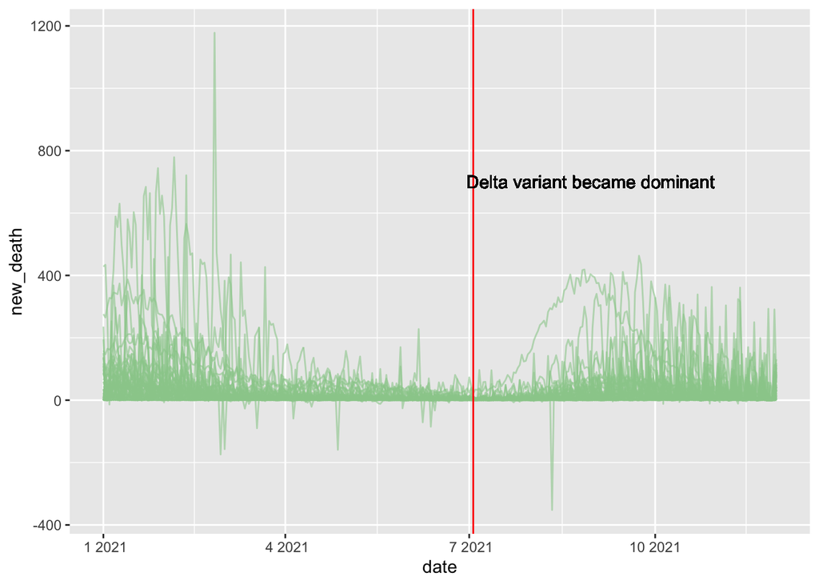

```r
comb%>%
  ggplot(aes(date,new_death,group=state))+
  geom_line(color='darkseagreen3',alpha=0.6)+
  geom_vline(xintercept=as.Date("2021-07-03"),color="red")+
  geom_text(aes(x=as.Date("2021-08-30"),y=700,label="Delta variant became dominant"))
```

Now, we are going to do some visualizations using maps.

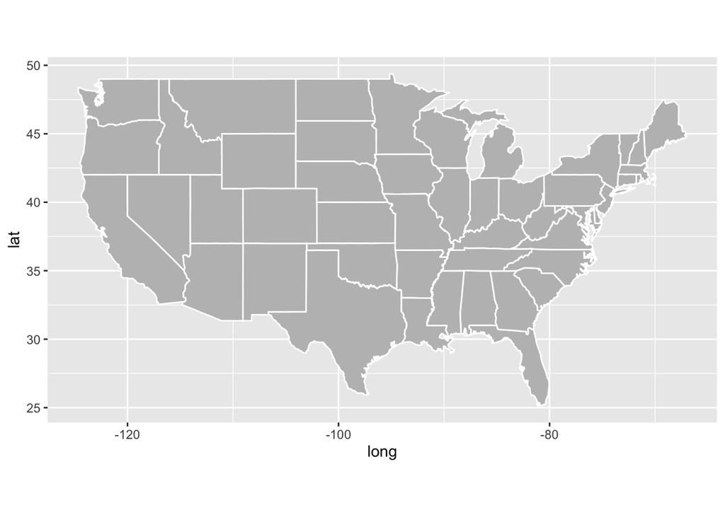

```r
# Pull out us state map data frame
us_states <- map_data("state")

us_states %>% ggplot(aes(x = long, y = lat, fill = region, group = group)) +
              geom_polygon(color = "white", fill = "grey") +
              coord_fixed(1.3) +
              guides(fill = FALSE)
```

Before joining the map data with the CDC data, we need to make sure that the states match successfully with each other whenever possible.

```r
x <- case_death$state
case_death <- case_death %>% mutate(region = tolower(state.name[match(x, state.abb)]))
y <- vaccine$state
vaccine <- vaccine %>% mutate(region = tolower(state.name[match(y, state.abb)])) %>%
  mutate()
```

Then we can combine the two dataset using join functions.

```r
# Choose two dates (one before delta dominant, one after)
dates <- c(ymd("2021-06-01", "2021-09-01"))

# Filter case_death data for the two dates and join with us_states data frame.
comb_cd <- case_death %>% filter(date %in% dates)
comb_cd <- left_join(comb_cd, us_states, by = "region")

# Filter vaccine data for the two dates and join with us_states data frame.
comb_vac <- vaccine %>% filter(date %in% dates)
comb_vac <- left_join(comb_vac, us_states, by = "region")
```

First we explore the map of new cases and deaths.

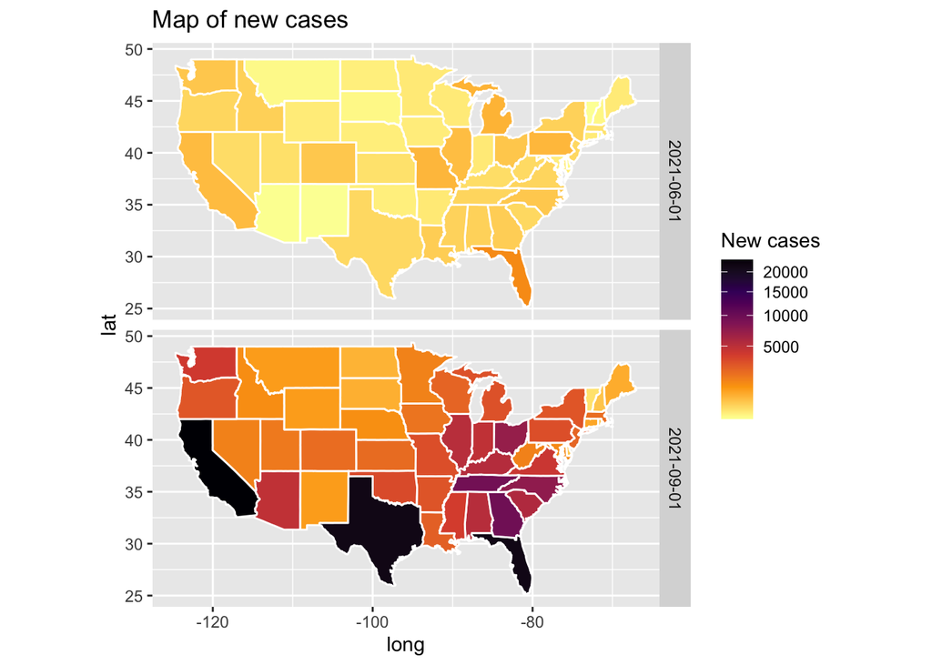

```r
# Heatmap of new cases on June 1, 2021 and Sept. 1, 2021.
comb_cd %>% ggplot(aes(x = long, y = lat, group = group, fill = new_case)) +
  geom_polygon(color = "white") +
  coord_fixed(1.3) +
  facet_grid(date ~ .) +
  ggtitle("Map of new cases") +
  scale_fill_viridis_c(name = "New cases", option = "inferno", direction = -1, trans = "sqrt")
```

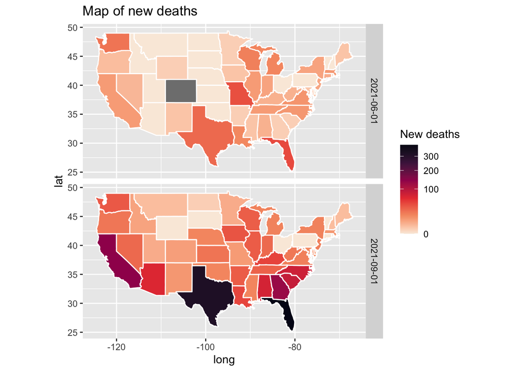

```r
# Heatmap of new deaths on June 1, 2021 and Sept. 1, 2021.
comb_cd %>% ggplot(aes(x = long, y = lat, group = group, fill = new_death)) +
  geom_polygon(color = "white") +
  coord_fixed(1.3) +
  facet_grid(date ~ .) +
  ggtitle("Map of new deaths") +
  scale_fill_viridis_c(name = "New deaths", option = "rocket", direction = -1, trans = "sqrt")
```

Then we explore the map of vaccination.

```r
# Filter case_death data on Sept. 1, 2021 and join with us_states data frame.
comb_cd <- case_death %>% filter(date == "2021-09-01")
comb_cd <- left_join(comb_cd, us_states, by = "region")

# Filter vaccine data for the two dates and join with us_states data frame.
comb_vac <- vaccine %>% filter(date == "2021-09-01")
comb_vac <- left_join(comb_vac, us_states, by = "region")
```

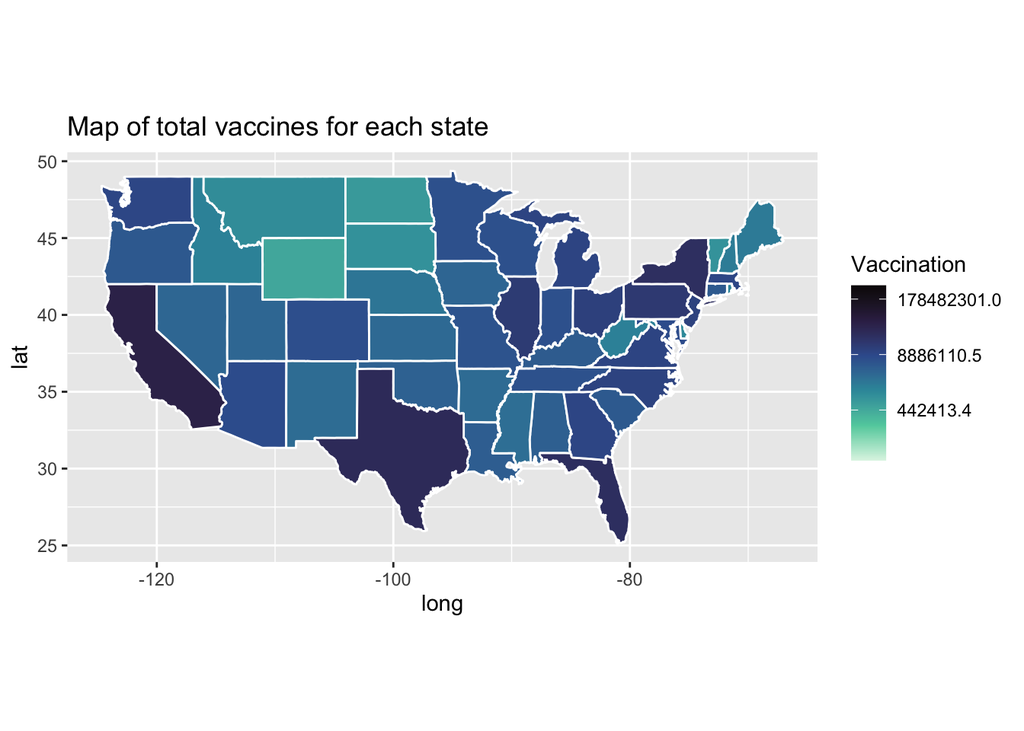

```r
# Heatmap of vaccine (regardless of brands) on June 1, 2021 and Sept. 1, 2021.
comb_vac %>% ggplot(aes(x = long, y = lat, group = group, fill = Administered)) +
  geom_polygon(color = "white") +
  coord_fixed(1.3) +
  ggtitle("Map of total vaccines for each state") +
  scale_fill_viridis_c(name = "Vaccination", option = "mako", direction = -1, trans = "log")
```

See the difference between vaccine brands.

```r
# Heatmap of vaccine (Moderna) on Sept. 1, 2021.
p1 <- comb_vac %>% ggplot(aes(x = long, y = lat, group = group, fill = Administered_Moderna)) +
  geom_polygon(color = "white") +
  coord_fixed(1.3) +
  ggtitle("Map of Moderna vaccinations") +
  scale_fill_viridis_c(name = "Vaccination", option = "mako", direction = -1, trans = "log")
```

```r
# Heatmap of vaccine (Pfizer) on Sept. 1, 2021.
p2 <- comb_vac %>% ggplot(aes(x = long, y = lat, group = group, fill = Administered_Pfizer)) +
  geom_polygon(color = "white") +
  coord_fixed(1.3) +
  ggtitle("Map of Pfizer vaccinations") +
  scale_fill_viridis_c(name = "Vaccination", option = "mako", direction = -1, trans = "log")
```

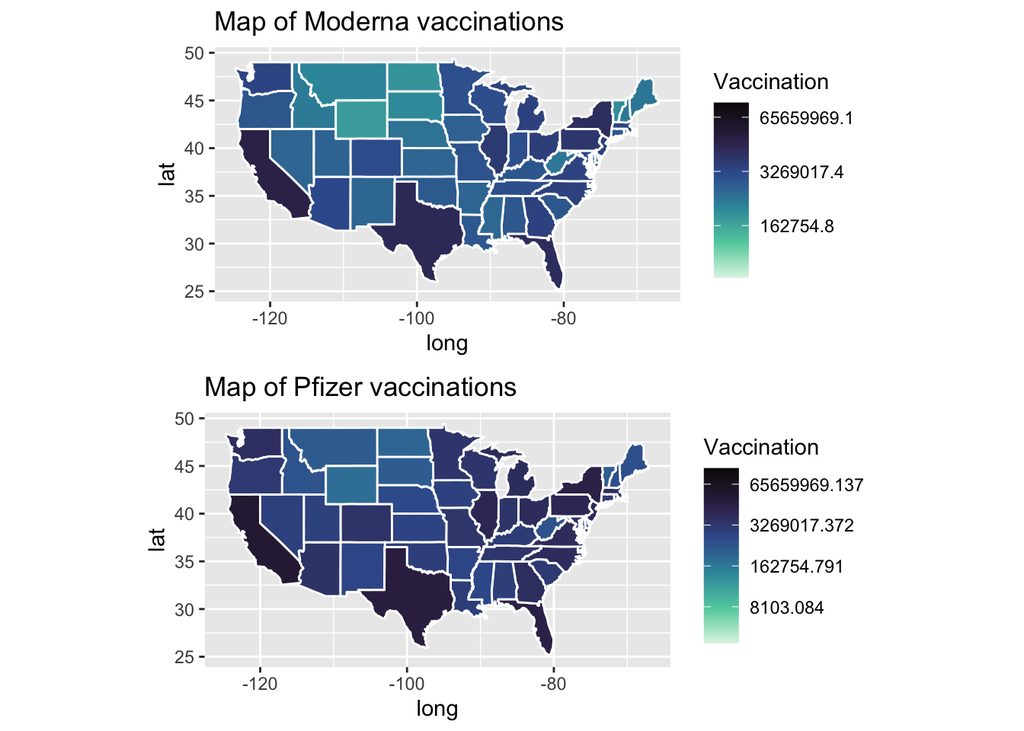

```r
grid.arrange(p1, p2, ncol = 1)
```

Classify the number of new cases into three categories (1: new case<=10000 on that day, 2: 10000<new case<=20000 on that day, 3: new case>20000 on that day) Also classify the number of new deaths into three categories (1: new death<=200 on that day, 2: 200<new death<=400 on that day, 3: new death>400 on that day)

```r
clascomb<-comb%>%
  mutate(new_case_clas=ifelse(new_case<=10000,1,ifelse(new_case>20000,3,2)))%>%
  mutate(new_death_clas=ifelse(new_death<=200,1,ifelse(new_death>400,3,2)))
```

Randomly divide the table into one train set (70% data) and one test set(30% data)

```r
inTrain   <- createDataPartition(y = clascomb$new_case, p = 0.7, times = 1, list = FALSE)
train_set <- slice(clascomb, inTrain)
test_set  <- slice(clascomb, -inTrain)
```

Classification using decision tree model

```r
rpart_fit <- rpart(new_case_clas ~ Administered, data = train_set)
rpart_preds <- predict(rpart_fit, test_set)
rpart_res<-ifelse(rpart_preds<1.5,1,ifelse(rpart_preds>=2.5,3,2))
#rpart_preds
confusionMatrix(data = as.factor(rpart_res), reference = as.factor(test_set$new_case_clas),positive="1")
```

```
## Confusion Matrix and Statistics
##
##           Reference
## Prediction    1    2    3
##          1 4924   54   19
##          2    2    8    1
##          3    0    0    0
##
## Overall Statistics
##
##                Accuracy : 0.9848
##                  95% CI : (0.981, 0.988)
##     No Information Rate : 0.9836
##     P-Value [Acc > NIR] : 0.2739
##
##                   Kappa : 0.18
##
##  Mcnemar's Test P-Value : 9.937e-15
##
## Statistics by Class:
##
##                      Class: 1 Class: 2 Class: 3
## Sensitivity            0.9996 0.129032 0.000000
## Specificity            0.1098 0.999393 1.000000
## Pos Pred Value         0.9854 0.727273      NaN
## Neg Pred Value         0.8182 0.989194 0.996006
## Prevalence             0.9836 0.012380 0.003994
## Detection Rate         0.9832 0.001597 0.000000
## Detection Prevalence   0.9978 0.002196 0.000000
## Balanced Accuracy      0.5547 0.564213 0.500000
```

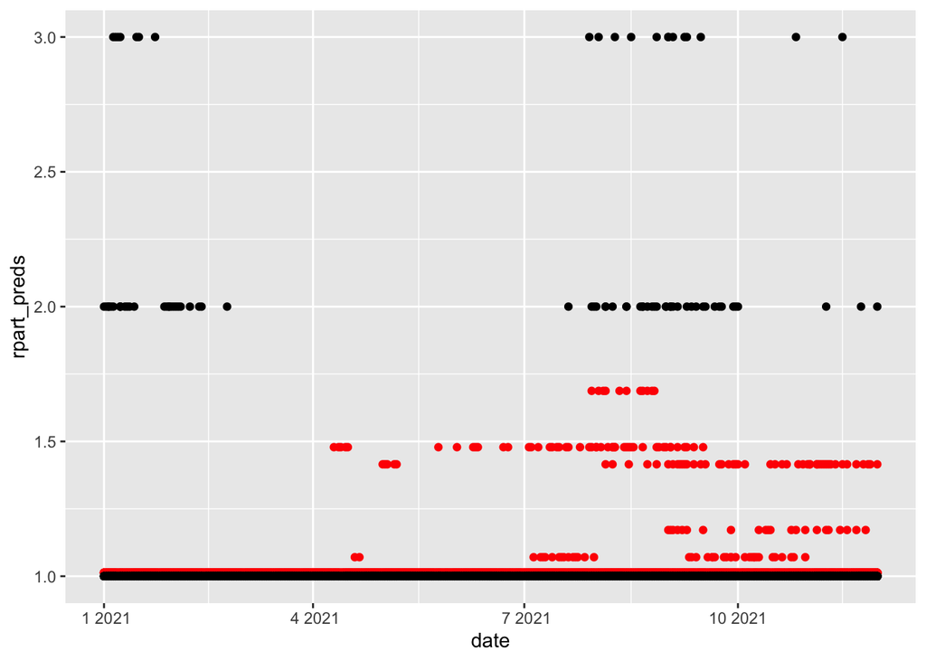

```r
test_set%>%
  ggplot()+geom_point(aes(date,rpart_preds),color="red")+geom_point(aes(date,new_case_clas))
```

Classification using random forest model

```r
rf_fit <- randomForest(new_case_clas ~ Administered, data = train_set)
rf_preds <- predict(rf_fit, test_set)
rf_res<-ifelse(rf_preds<1.5,1,ifelse(rf_preds>=2.5,3,2))
#rpart_preds
confusionMatrix(data = as.factor(rf_res), reference = as.factor(test_set$new_case_clas),positive="1")
```

```
## Confusion Matrix and Statistics
##
##           Reference
## Prediction    1    2    3
##          1 4815   52   17
##          2  110   10    3
##          3    1    0    0
##
## Overall Statistics
##
##                Accuracy : 0.9635
##                  95% CI : (0.9579, 0.9685)
##     No Information Rate : 0.9836
##     P-Value [Acc > NIR] : 1
##
##                   Kappa : 0.096
##
##  Mcnemar's Test P-Value : 2.844e-08
##
## Statistics by Class:
##
##                      Class: 1 Class: 2  Class: 3
## Sensitivity            0.9775 0.161290 0.0000000
## Specificity            0.1585 0.977153 0.9997995
## Pos Pred Value         0.9859 0.081301 0.0000000
## Neg Pred Value         0.1048 0.989355 0.9960056
## Prevalence             0.9836 0.012380 0.0039936
## Detection Rate         0.9615 0.001997 0.0000000
## Detection Prevalence   0.9752 0.024561 0.0001997
## Balanced Accuracy      0.5680 0.569222 0.4998998
```

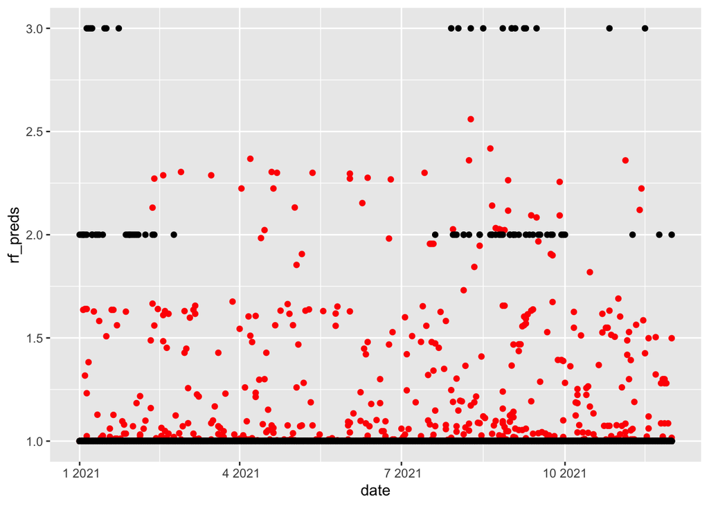

```r
test_set%>%
  ggplot()+geom_point(aes(date,rf_preds),color="red")+geom_point(aes(date,new_case_clas))
```

Regression using random forest

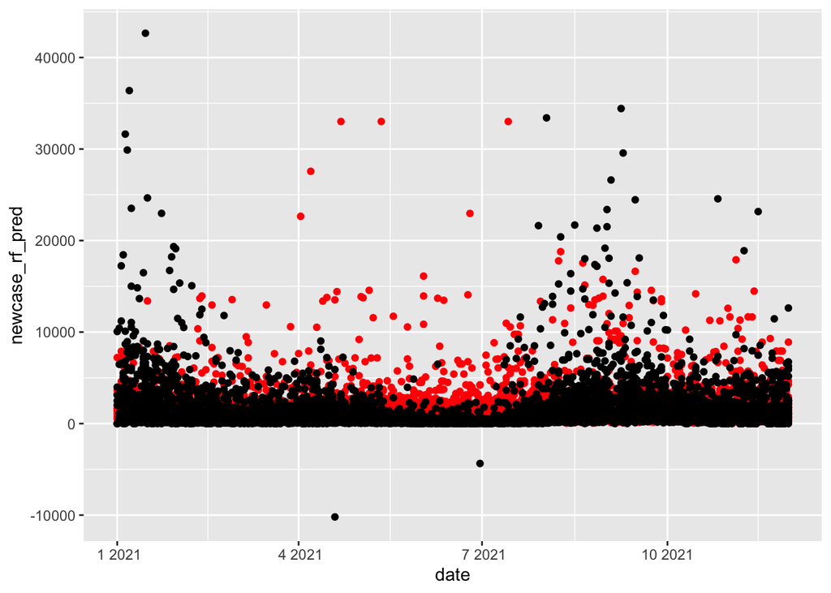

```r
newcase_rf<-randomForest(new_case~Administered, data=train_set)
newcase_rf_pred<-predict(newcase_rf,test_set)
test_set%>%
  ggplot()+geom_point(aes(date,newcase_rf_pred),color="red")+geom_point(aes(date,new_case))
```

Divide the table into trainset and testset by date (cutoff point: 2021-07-31)

```r
trainset<-clascomb%>%
  filter(date <= as.Date("2021-7-31"))
testset<-clascomb%>%
  filter(date >as.Date("2021-07-31"))
#trainset
```

Machine learning using linear regression

```r
linearfit <- lm(new_case ~ Administered, data = trainset)
linear_pred <- predict(linearfit, testset)
data.frame(
  RMSE = RMSE(linear_pred, testset$new_case),
  R2 = R2(linear_pred, testset$new_case)
)
```

```
##       RMSE        R2
## 1 2959.376 0.3180471
```

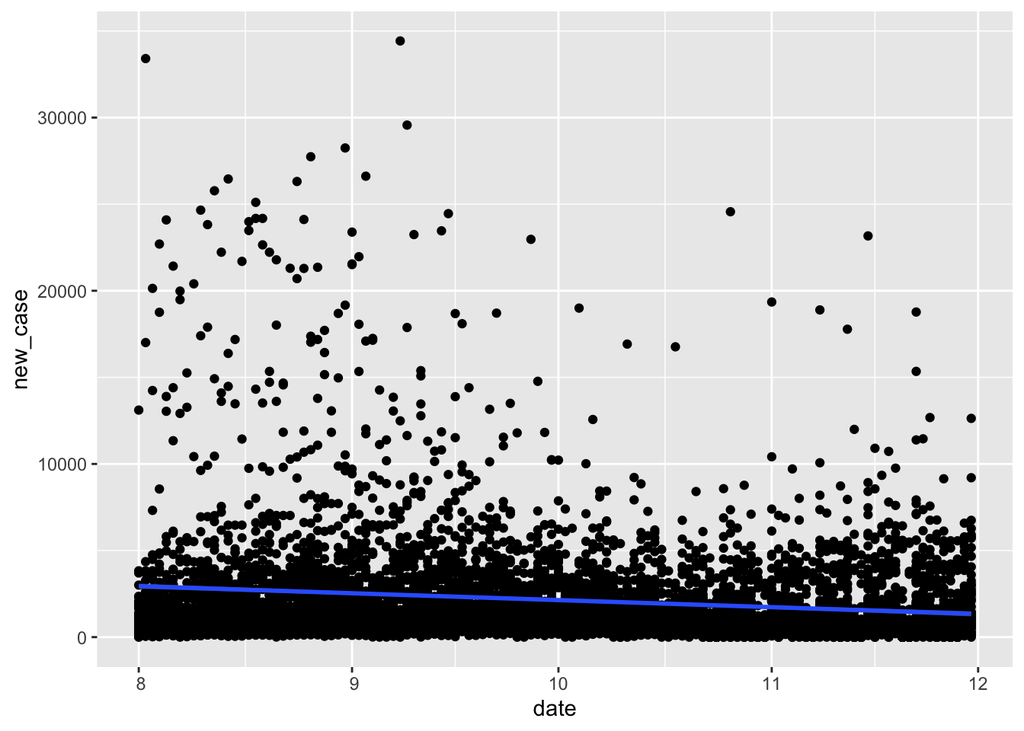

```r
#testset%>%
#  ggplot()+geom_line(aes(date,rpart_preds1),color="red")+geom_point(aes(date,new_case))
ggplot(testset, aes(date, new_case) ) +
  geom_point() +
  stat_smooth(method = lm, formula = y ~ x)
```

Machine learning using random forest

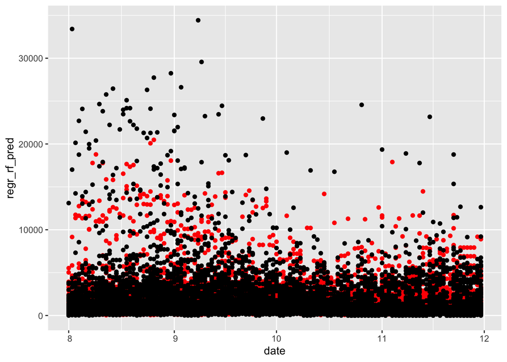

```r
regr_rf<-randomForest(new_case~Administered, data=trainset)
regr_rf_pred<-predict(newcase_rf,testset)
testset%>%
  ggplot()+geom_point(aes(date,regr_rf_pred),color="red")+geom_point(aes(date,new_case))
```

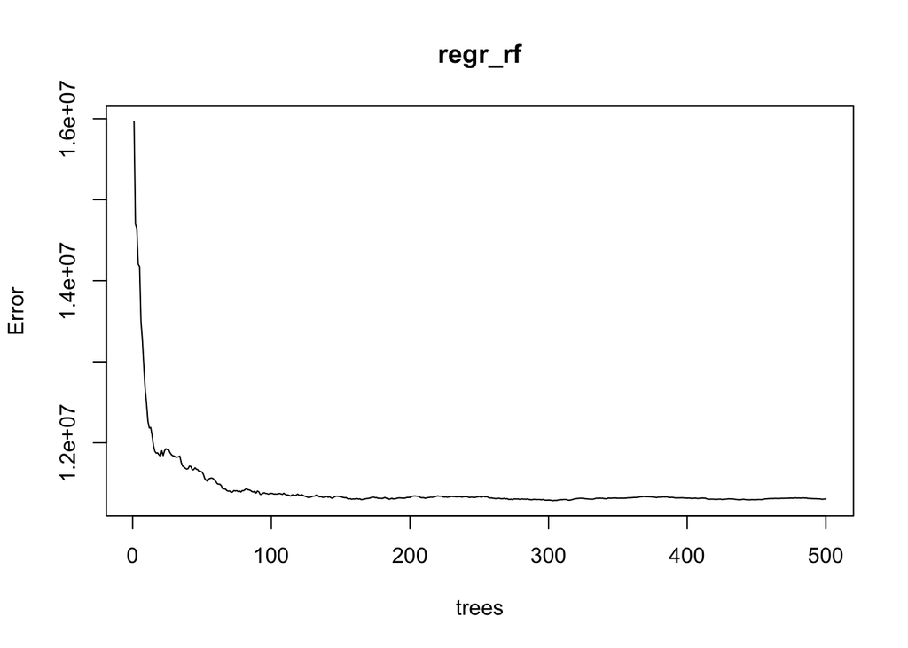

```r
plot(regr_rf)
```

```r
sqrt(sum((regr_rf_pred - testset$new_case)^2) / nrow(testset))
```

```
## [1] 2054.119
```